# Лабораторная работа №3

Дискреционное разграничение прав в Linux. Основные атрибуты

Устинова В. В.

Российский университет дружбы народов, Москва, Россия

06 марта 2026

# Информация

## Докладчик

- Устинова Виктория Вадимовна
- студент НПИбд-01-24
- Российский университет дружбы народов

## Цель работы

Получение практических навыков работы в консоли с атрибутами файлов, закрепление теоретических основ дискреционного разграничения доступа в современных системах с открытым кодом на базе ОС Linux1.

## Задание

Выполнить: последовательность выполнения работы. написать отчет.

## Выполнение лабораторной работы

В установленной при выполнении предыдущей лабораторной работы операционной системе создайте учётную запись пользователя guest

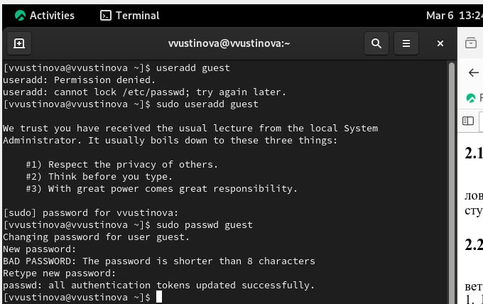

Дополнительно задаем пароль для пользователя, и входим в систему от нового п.

## Выполнение лабораторной работы

Определите директорию, в которой вы находитесь, командой pwd, уточните имя вашего пользователя командой, Сравните вывод id с выводом команды groups

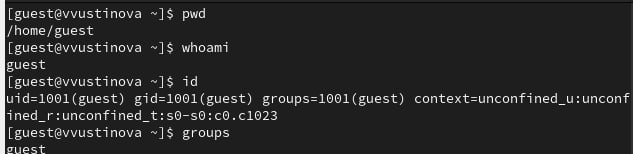

Мы по именем guest, находимся в домашней директории

## Выполнение лабораторной работы

Просмотрите файл /etc/passwd командой

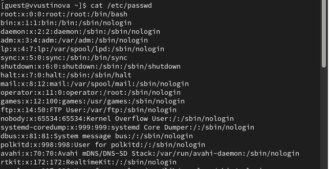

смотрим файл

## Выполнение лабораторной работы

Определите существующие в системе директории командой, Проверьте, какие расширенные атрибуты установлены на поддиректориях, находящихся в директории /home, командой:

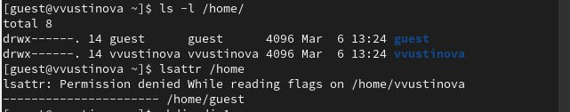

вводим команды

## Выполнение лабораторной работы

Создайте в домашней директории поддиректорию dir1 командой, определите командами ls -l и lsattr, какие права доступа и расширенные атрибуты были выставлены на директорию dir1.

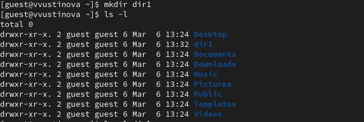

drwxr-xr-x

## Выполнение лабораторной работы

Определите командами ls -l и lsattr, какие права доступа и расширенные атрибуты были выставлены на директорию dir1.

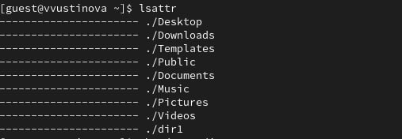

Выполняем команду lsattr

## Выполнение лабораторной работы

Снимите с директории dir1 все атрибуты командой, и проверьте с её помощью правильность выполнения команды, попытайтесь создать в директории dir1 файл file1 командой

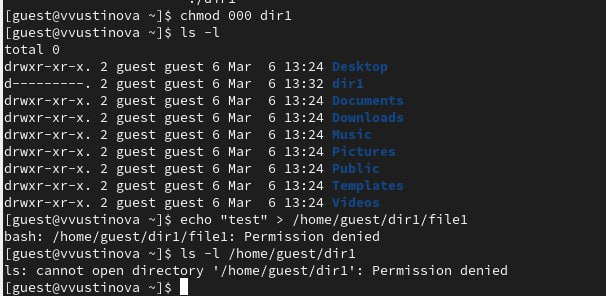

Нам нельзя создать файл после снятия прав

## Выводы

У нас получилось получить практические навыки работы в консоли с атрибутами файлов, закрепить теоретические основы дискреционного разграничения доступа в современных системах с открытым кодом на базе ОС Linux1.